# HTTomo framework overview and HPC benchmarks

Data Analysis Group meeting, 19.11.2026

Imaging Team

Diamond Light Source, UK

[figure not shown]

[Diamond Light Source](https://www.diamond.ac.uk/Home.html)

[figure not shown]

[Tomopedia](https://tomopedia.github.io/software/)

## What is HTTomo?

**High-throughput tomographic software HTTomo is open-source software for parallel-beam tomography data processing and reconstruction.**

It is designed for high-throughput processing, i.e., handling large amounts of scan data with computational efficiency.

**Load scan data → Correct the images → Reconstruct → Save results**

### You provide

- **Scan data:** X-ray images taken at different angles saved into a data file.
- **A processing recipe:** a YAML text file listing the steps or methods and their parameters.

### HTTomo handles

- Running the processing steps in recipe order.
- Managing data and memory, with support for GPU processing and HPC clusters.

## Input and output in tomography

[video not shown]

## What else is HTTomo?

[figure not shown]

- Written in **Python**, using object-oriented design.
- A framework for **parallel data processing**.
- Designed to **scale to increasingly large datasets**.
- Supports **plug-and-play processing methods** from TomoPy and in-house GPU-accelerated libraries.
- Separates processing from an **independent, replaceable user interface**.

[HTTomo on GitHub](https://github.com/DiamondLightSource/httomo)

## HTTomo framework

- OpenMPI-based framework for **parallel processing** of tomography data
- Chunks, blocks and sections for **data partitioning**
- HTTomo memory management for **CPU and GPU** processing
- HTTomo wrappers for **plug-and-play** processing methods
- Reconstruction ecosystem
- HTTomo features

## Open MPI in HTTomo

Open MPI is an open-source implementation of the **Message Passing Interface** standard. It launches independent processes—called **MPI ranks**—and lets them exchange data and coordinate work.

- The same program runs in every rank
- Each rank processes a different part of the dataset
- Ranks can run on one workstation or across several HPC nodes

### HTTomo uses MPI as its **high-level parallelisation layer**:

**Rank 0** GPU 0

**Rank 1** GPU 1

**Rank 2** GPU 2

**Rank 3** GPU 3

- Distributes large tomography datasets as chunks across ranks
- Assigns ranks to CPUs or GPUs for concurrent processing
- Coordinates distributed I/O, processing and reconstruction

## HTTomo data management

### Larger 3D blocks within the memory budget

- HTTomo divides data **chunks** into 3D **blocks** for GPU processing.
- Uses blocks as large as safely fit in GPU memory
- Memory estimators use **free VRAM** and each method’s requirements to determine how many slices fit.
- The **most memory-demanding method in a section** limits the block size.

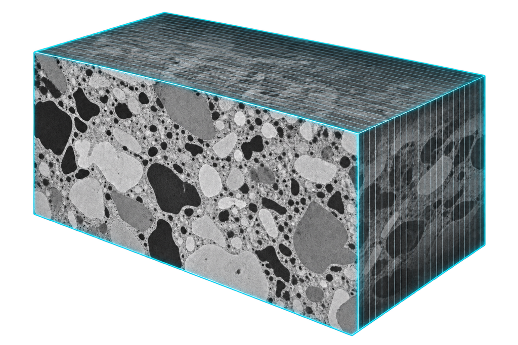

### Method chains to reduce transfers

HTTomo chains compatible GPU methods within a section, keeping each block on the GPU between methods.

**For each block:**

1. Transfer the block to the GPU.
2. Run the GPU method chain.
3. Return the result to the CPU only when it is needed.

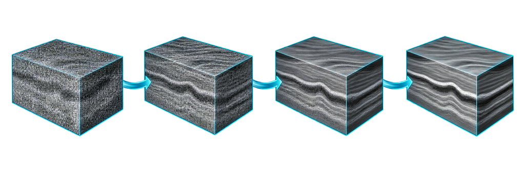

[figure not shown]

[More on reslice](https://diamondlightsource.github.io/httomo/introduction/concepts/reslice.html)

[figure not shown]

[More on sections](https://diamondlightsource.github.io/httomo/introduction/concepts/sections.html)

[figure not shown]

[HTTomo features](https://diamondlightsource.github.io/httomo/howto/httomo_features.html)

## Padding enables true 3D processing

A 3D method needs neighbouring slices. Padding preserves that context when HTTomo splits a volume into blocks.

### Why padding is needed

- A **2D method** processes each frame independently, so a block boundary does not interrupt its neighbourhood.
- A **3D method** uses information along all three axes. At a block edge, it needs slices held in the neighbouring block.
- HTTomo pads the block with this surrounding data, allowing the method to satisfy its boundary conditions and avoid seam-like artefacts.

### Denoising comparison

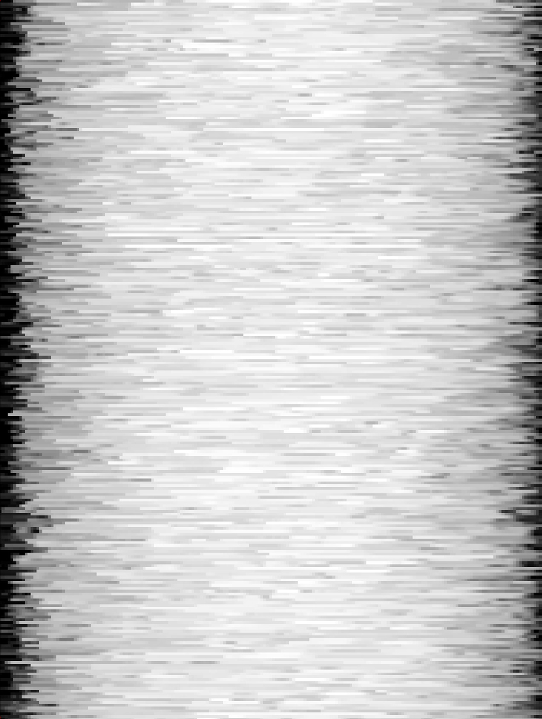

2D denoising method

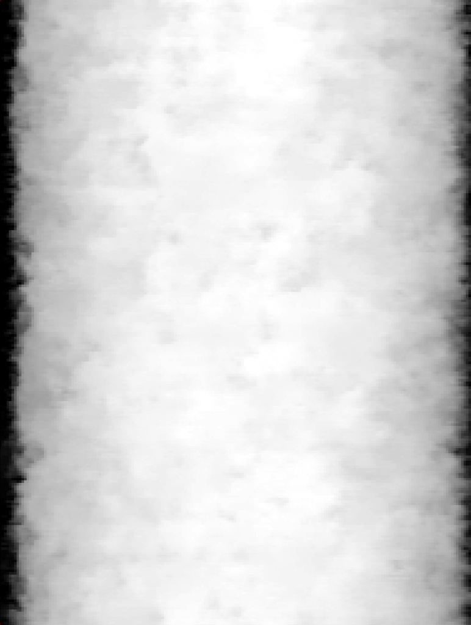

3D denoising with padding

- Consistent resolution in all three dimensions
- Better removal of volumetric artefacts and improved contrast
- Access to advanced 3D filters and iterative reconstruction methods

## Sweeping functionality

### What is it

[HTTomo parameter sweeping](https://diamondlightsource.github.io/httomo/howto/httomo_features/parameter_sweeping.html) runs a method on the same input data using several values of one parameter, allowing you to compare the results and choose a suitable value.

### When to use

Parameter sweeping is useful when automatic estimation fails or is unavailable. For example, if an automatic method cannot reliably estimate the *center of rotation of a sample*, sweeping lets you compare reconstructions and select a suitable value.

### HTTomo feature

Parameter sweeping uses a separate (non high-throughput) runner in HTTomo, designed for debugging and parameter tuning.

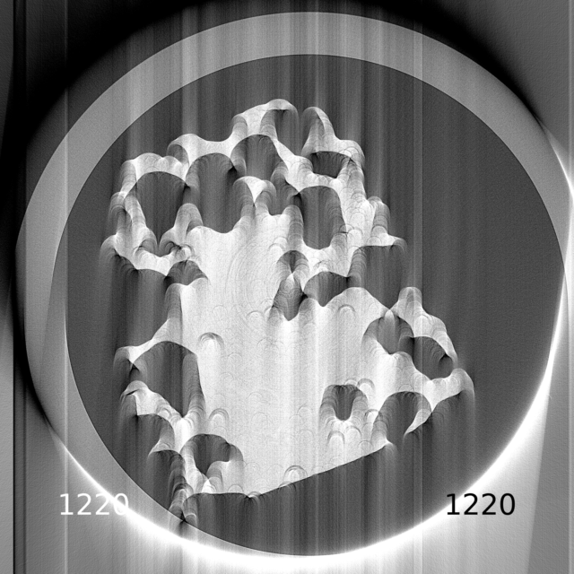

Changing CoR changes the reconstruction. Each frame shows its trial value.

## HTTomo for GPU processing

HTTomo is **designed** to perform GPU-accelerated processing. This is the **preferred approach** for achieving high-throughput processing.

GPU performance comes from:

- GPU-accelerated methods: pre-processing and reconstruction from the [HTTomoLibGPU](https://diamondlightsource.github.io/httomolibgpu/) and ToMoBAR libraries.
- Efficient GPU utilisation
- Fewer transfers between CPU and GPU memory

## GPU pre-processing: execution time

GPU implementations are faster for all five tested methods, including amortised transfers.

HTTomoLibGPU on Blackwell GPU versus TomoPy on a 96-core AMD EPYC CPU.

[figure not shown]

Kazantsev et al., manuscript in preparation.

## GPU pre-processing: including transfer costs

Including transfers, the tested GPU methods achieve **6.7–29.2× speedup** over CPU implementations.

[figure not shown]

Kazantsev et al., manuscript in preparation.

## GPU reconstruction: execution time

**LPRec: 1.5 s**, compared with 4.2 s for 3D FBP and 9.3 s for slice-wise FBP in this test.

Data chunk: `[1800, 200, 2560]` · NVIDIA V100 GPU

[figure not shown]

## Workstation pipeline runtimes

**HTTomo: 154.5 s** end to end; TomoCuPy is fastest in this comparison at 111 s.

[figure not shown]

## Single node: where method time is spent

**Intermediate saving (33.0 s)** and **stripe removal (25.3 s)** are the largest method costs per rank.

Four NVIDIA RTX PRO 6000 Blackwell GPUs · 84 GB dataset

[figure not shown]

Kazantsev et al., manuscript in preparation.

## Single node: processing and data movement

**Read/staging + disk writes: 98.9 s per rank**, compared with 43.4 s of GPU kernel time.

Four Blackwell GPUs · elapsed runtime: 189.8 s · timers may overlap

[figure not shown]

Kazantsev et al., manuscript in preparation.

## Multiple nodes: pipeline runtime

With **8 GPUs per node**, two nodes reduce runtime from **134.4 s to 68.1 s**.

[figure not shown]

Kazantsev et al., manuscript in preparation.

## Scaling from one to two nodes

Doubling the nodes gives **1.83–2.12× speedup** at the same GPU count per node.

Each point compares one versus two nodes using the indicated GPUs per node.

[figure not shown]

Kazantsev et al., manuscript in preparation.

## What’s next for HTTomo?

### Reducing CPU memory usage

- **Current limit:** each process holds a full data chunk in RAM. Larger inputs require more RAM or distribution across more nodes.
- **Proposed redesign:** load smaller **subchunks** into CPU memory and release them after processing.

[figure not shown]

Requires changes to loading, scheduling and reslicing; methods with wider data dependencies need special handling.

## What’s next for HTTomo?

### Supporting bespoke scanning geometries

[figure not shown]

## Laminography reconstruction at DIAD

Including the **20° sample-axis tilt** reduces reconstruction artefacts with **ToMoBAR FBP**.

### DIAD acquisition geometry

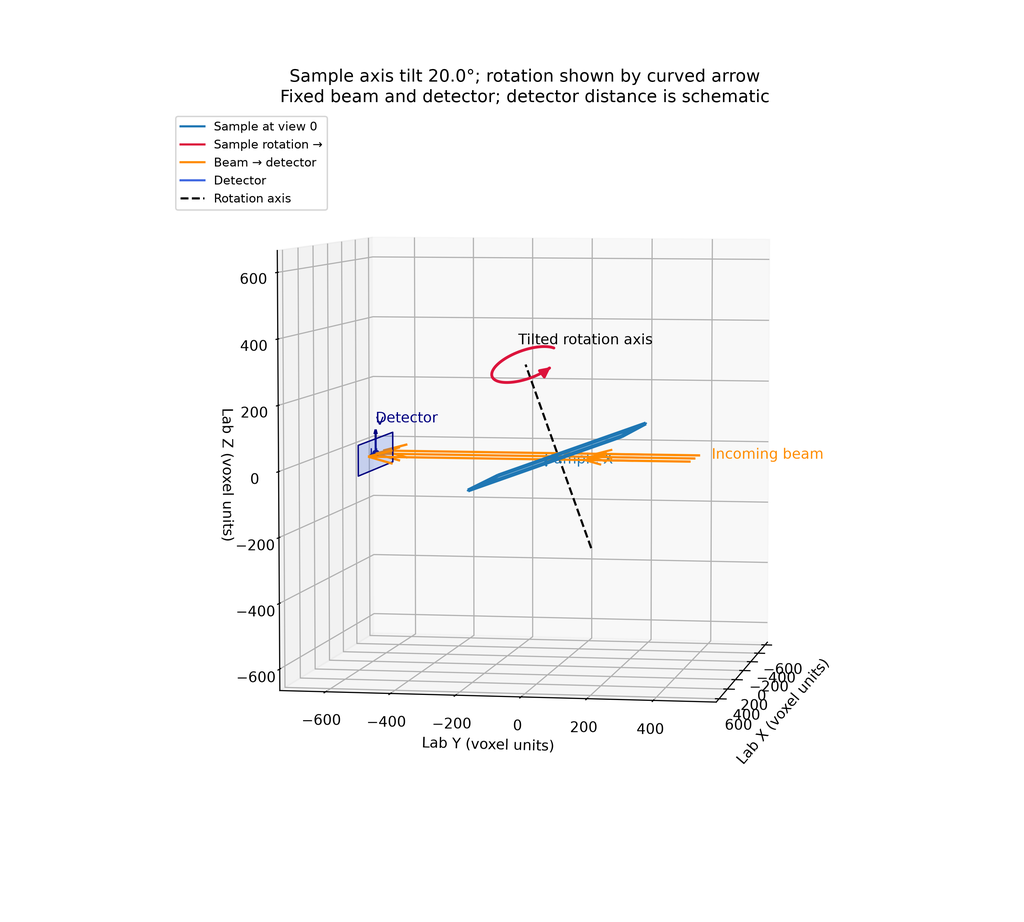

20° axis tilt = **70° beam–axis angle**

### Without tilt in the reconstruction model

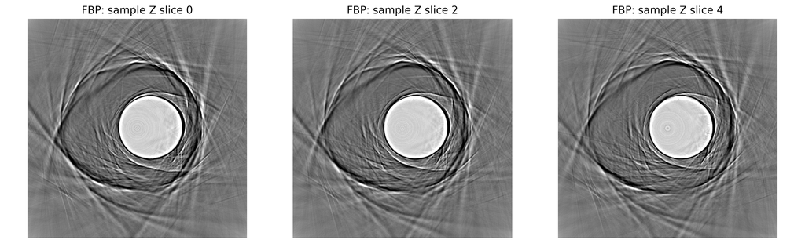

### With the 20° sample-axis tilt

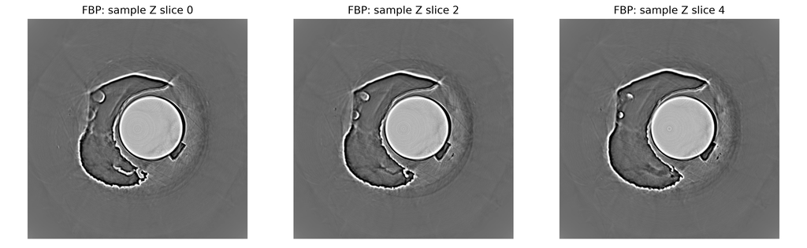

## Acknowledgements

HTTomo is a collective effort by software/method developers and beamline scientists at Diamond Light Source.

### Software developers:

- **Daniil Kazantsev**
- **Yousef Moazzam**
- **Naman Gera**
- **Jessica Verschoyle**
- **Timothy Poon**
- **Benedikt Daurer**

### Beamline community

We thank Diamond’s beamline scientists for:

- Representative datasets and scientific requirements
- Software testing and validation on real experiments
- Feedback that improves methods, pipelines and usability

### Diamond Light Source

We acknowledge Diamond Light Source and its technical teams for providing:

- Beamline and experimental facilities
- HPC and GPU computing resources
- Data infrastructure and operational support

Thank you!

[figure not shown]

[figure not shown]